# Outlier and Venn Diagram Results from Pinus contorta at different cutoffs FOR BAYENV SNPS THAT OVERLAP WITH LFMM ANALYSIS (see emails from Simon)

Katie Lotterhos

April 16, 2015

Data used here is stored on hulk at /data/seqcap/pine/bwa_pseudo/round2_bams/var_out_GATK3_allhet_pine688_ALL.summary.ALL.annots.sorted.GOOD.window_RESULTS. It was transferred to my laptop to make the markdown files.

In this analysis, we ran bayenv2 (Gunther and Coop 2013) on over 1,000,000 SNPs from the Pine sequence capture. We had 22 environmental variables of biological interest. In this document, I subset the results to coincide with the SNPs that were also run for LFMM, so we could determine whether the story depended on the method or on the filtering criteria.

For the most part, these results are consistent with the entire set of SNPs (but still different in some instances from LFMM), indicating that there are some subtle differences between the programs in how they determine whether a SNP is significantly associated with the environment. **Reasons for this are explained at the end of the file.**

### The SNP dataset

Here are the column names in the SNP dataset: (the ones named after the environments contain Bayes Factors. “rho” represents Spearman’s rho, which indicates the correlation between the reference SNP frequency and the environment.)

```r
#filename <- "var_out_GATK3_allhet_pine688_ALL.summary.ALL.annots.sorted.GOOD.window.3xbf.log10"
#filename <- "../pine_data/var_out_GATK3_allhet_pine688_ALL.summary.ALL.annots.sorted.GOOD.window_RESULTS"
filename <- "../pine_data/bayenv.lfmmbeagle.res"
### read in file with log-BF
  if(!("f2" %in% ls())){
    f2<- read.table(filename, header=TRUE, comment.char="&")
  }

  names(f2)
```

```
##   [1] "gcontig"                 "pos_gcontig"
##   [3] "X.annotation"            "paralogy_rank"
##   [5] "tcontig"                 "pos_tcontig"
##   [7] "gmap_percentID"          "offtarget_dist"
##   [9] "num_alleles"             "num_ind"
##  [11] "num_comm_gtype"          "major_allele"
##  [13] "major_num"               "major_freq"
##  [15] "minor_allele"            "minor_num"
##  [17] "minor_freq"              "freq_hetzyg"
##  [19] "MAP_dir1"                "MAP_dir2"
##  [21] "MAP_MgGm"                "noncode_in_covar"
##  [23] "MQ"                      "haplotype_score"
##  [25] "FS"                      "MQRankSum"
##  [27] "ReadPosRankSum"          "allele_balance"
##  [29] "window_stat"             "scaffold"
```

[output cut: 56 more lines]

```r
  #These new lines of code are to take the bayenv subset that is the same as lfmm
  lfmmcols <- grep("lfmm.beagle", names(f2))
  a<- is.na(f2[,lfmmcols])
  head(a)
```

```
##   LAT.z.lfmm.beagle LAT.q.lfmm.beagle LONG.z.lfmm.beagle
## 1              TRUE              TRUE               TRUE
## 2              TRUE              TRUE               TRUE
## 3              TRUE              TRUE               TRUE
## 4              TRUE              TRUE               TRUE
## 5              TRUE              TRUE               TRUE
## 6              TRUE              TRUE               TRUE
##   LONG.q.lfmm.beagle ELEVATION.z.lfmm.beagle ELEVATION.q.lfmm.beagle
## 1               TRUE                    TRUE                    TRUE
## 2               TRUE                    TRUE                    TRUE
## 3               TRUE                    TRUE                    TRUE
## 4               TRUE                    TRUE                    TRUE
## 5               TRUE                    TRUE                    TRUE
## 6               TRUE                    TRUE                    TRUE
##   MAT.z.lfmm.beagle MAT.q.lfmm.beagle MWMT.z.lfmm.beagle
```

[output cut: 83 more lines]

```r
  a1 <- rowSums(a)==length(lfmmcols) #if all lfmm columns have NA, this is TRUE
  f2b <- f2[a1==FALSE,]  # remove the SNPs that were not run in LFMM
  nrow(f2b)
```

```
## [1] 252120
```

```r
env <- read.table("../pine_data/sprucePineEnvi.clusters", header=TRUE)
env <- env[order(env$G4),]
```

The total number of SNPs used for analysis:

```r
nrow(f2b)
```

```
## [1] 252120
```

The Bayes factors from all environments were pooled to calculate cutoffs for the different quartiles of the BF distribution. Here are the BF cutoffs for those percentiles:

```r
### read in file with cutoffs
  cos <- read.table("../pine_data/var_out_GATK3_allhet_pine688_ALL.summary.ALL.annots.sorted.GOOD.window.3xbf.log10.cutoffs", header=TRUE)
  cos <- rev(cos)
  cos[1] <- -99
  names(cos)[1] <- "All"
  cos
```

```
##   All       V.90       V.95      V.99    V.999   V.9995   V.9999  V.99999
## 1 -99 -0.3575685 -0.1456535 0.4776421 1.729643 2.267576 4.122732 10.60902
```

And here are the quartiles for $X^TX$ (note that I haven’t done any analysis with these yet):

```r
### read in file with cutoffs
  cx <- read.table("../pine_data/var_out_GATK3_allhet_pine688_ALL.summary.ALL.annots.sorted.GOOD.window.3xbf.log10.XTXcutoffs", header=TRUE)
  cx
```

```
##   V.99999 V.9999   V.9995  V.999     V.99   V.95     V.90    max.V
## 1  328.05 316.07 307.4833 302.63 290.6767 285.77 283.9033 342.6967
```

#### Now loop through some these cutoffs and summarize the results for environment enrichment:

### Results for V.9995 percentile, which corresponds to a BF of 2.268 …

#### Venn diagrams of overlap among variables. Raw counts on left column, percentages on right column:

Note that the number in the bottom right corner of the Venn represents the number of SNPs that do not fit into any category and can be ignored.

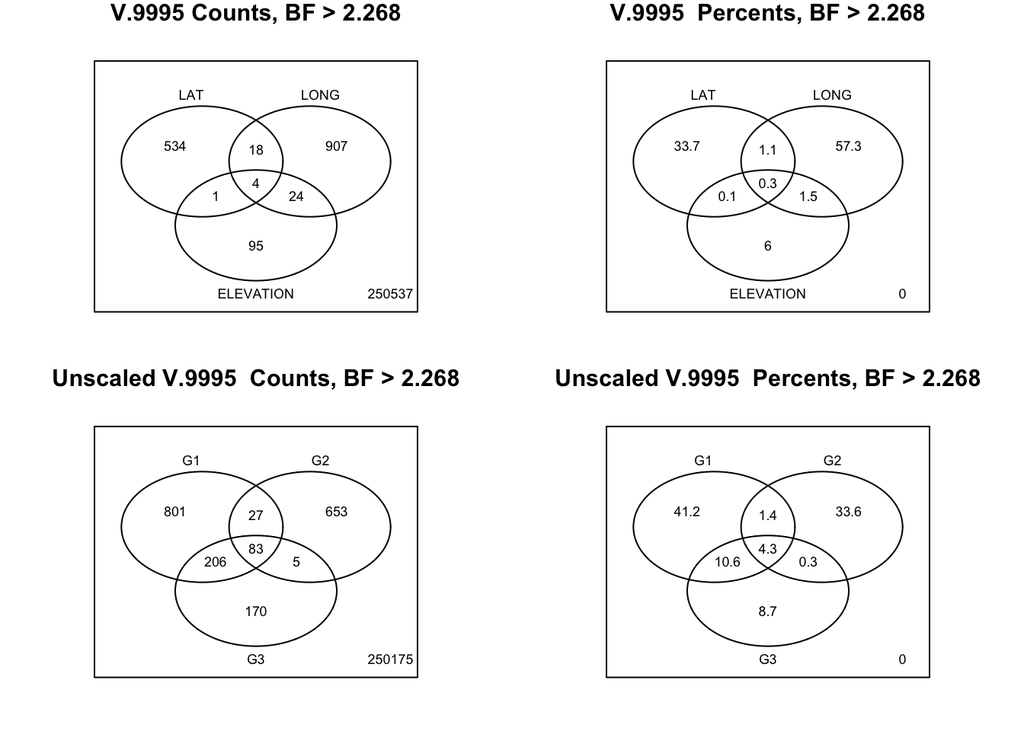

### Results for V.9999 percentile, which corresponds to a BF of 4.123 …

#### Venn diagrams of overlap among variables. Raw counts on left column, percentages on right column:

Note that the number in the bottom right corner of the Venn represents the number of SNPs that do not fit into any category and can be ignored.

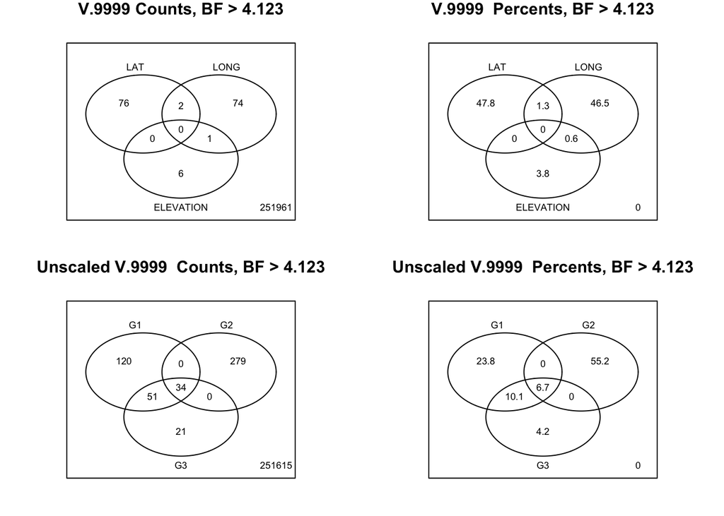

### Results for V.99999 percentile, which corresponds to a BF of 10.609 …

#### Total number of outliers (loci with BF above threshold in any one environment): 39

#### Venn diagrams of overlap among variables. Raw counts on left column, percentages on right column:

Note that the number in the bottom right corner of the Venn represents the number of SNPs that do not fit into any category and can be ignored.

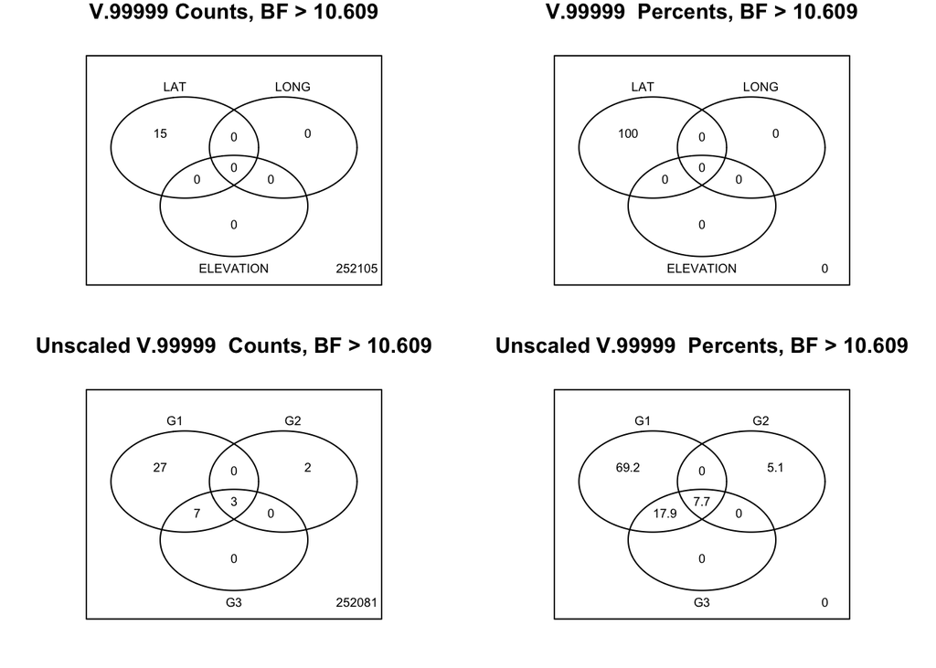

### Number of outliers based on different cutoffs

#### The number of outliers in each environmental variable

|  | enviAbb | enviDesc | numOutliers.All | numOutliers.V.99 | numOutliers.V.999 | numOutliers.V.9995 | numOutliers.V.9999 | numOutliers.V.99999 |
| --- | --- | --- | --- | --- | --- | --- | --- | --- |
| 1 | LAT | Latitude | 252120.00 | 7842.00 | 1144.00 | 557.00 | 78.00 | 15.00 |
| 2 | LONG | Longitude | 252120.00 | 15047.00 | 2032.00 | 953.00 | 77.00 | 0.00 |
| 3 | ELEVATION | Elevation | 252120.00 | 4810.00 | 361.00 | 124.00 | 7.00 | 0.00 |
| 4 | MAT | Mean ann. temp | 252120.00 | 4460.00 | 489.00 | 256.00 | 71.00 | 22.00 |
| 6 | MCMT | Mean coldest month | 252120.00 | 6877.00 | 1035.00 | 568.00 | 104.00 | 17.00 |
| 7 | TD | Temp difference | 252120.00 | 6733.00 | 1024.00 | 550.00 | 73.00 | 3.00 |
| 12 | DD_0 | Days < 0C | 252120.00 | 6021.00 | 848.00 | 444.00 | 78.00 | 15.00 |
| 19 | EMT | Extreme min. temp 30 years | 252120.00 | 6783.00 | 1157.00 | 646.00 | 160.00 | 37.00 |
| 8 | MAP | Mean annual precipitation | 252120.00 | 3106.00 | 291.00 | 109.00 | 17.00 | 0.00 |
| 9 | MSP | Mean summer precipitation | 252120.00 | 2408.00 | 508.00 | 343.00 | 80.00 | 0.00 |
| 10 | AHM | Anuual heat:moisture index | 252120.00 | 2125.00 | 548.00 | 435.00 | 179.00 | 1.00 |
| 11 | SHM | Summer heat:moisture index | 252120.00 | 3331.00 | 535.00 | 359.00 | 62.00 | 0.00 |
| 18 | PAS | Precipitation as snow | 252120.00 | 1853.00 | 85.00 | 25.00 | 1.00 | 0.00 |
| 20 | EXT | Extreme max. temp 30 years | 252120.00 | 2302.00 | 476.00 | 287.00 | 54.00 | 0.00 |
| 21 | Eref | Evaporation | 252120.00 | 3028.00 | 613.00 | 451.00 | 110.00 | 3.00 |
| 22 | CMD | Climate moisture deficit | 252120.00 | 2738.00 | 650.00 | 490.00 | 250.00 | 1.00 |
| 5 | MWMT | Mean warmest month | 252120.00 | 1664.00 | 109.00 | 40.00 | 4.00 | 0.00 |
| 13 | DD5 | Days > 5C | 252120.00 | 2146.00 | 160.00 | 85.00 | 27.00 | 0.00 |
| 14 | NFFD | # frost-free days | 252120.00 | 4090.00 | 633.00 | 355.00 | 81.00 | 10.00 |
| 15 | bFFP | Begin frost-free period | 252120.00 | 2492.00 | 169.00 | 72.00 | 6.00 | 0.00 |
| 16 | eFFP | End frost-free period | 252120.00 | 4327.00 | 597.00 | 326.00 | 94.00 | 8.00 |
| 17 | FFP | Frost-free period | 252120.00 | 3161.00 | 333.00 | 164.00 | 35.00 | 2.00 |

#### The number of outliers for just Lat, Long, and Elevation

|  | Category | numOutliers.All | numOutliers.V.99 | numOutliers.V.999 | numOutliers.V.9995 | numOutliers.V.9999 | numOutliers.V.99999 |
| --- | --- | --- | --- | --- | --- | --- | --- |
| 1 | LAT | 252120 | 7842 | 1144 | 557 | 78 | 15 |
| 2 | LONG | 252120 | 15047 | 2032 | 953 | 77 | 0 |
| 3 | ELEVATION | 252120 | 4810 | 361 | 124 | 7 | 0 |

#### The number of outliers for the three environmental groups

|  | Category | numOutliers.All | numOutliers.V.99 | numOutliers.V.999 | numOutliers.V.9995 | numOutliers.V.9999 | numOutliers.V.99999 |
| --- | --- | --- | --- | --- | --- | --- | --- |
| 1 | Group 1 (temp) | 252120 | 14370 | 2180 | 1117 | 205 | 37 |
| 2 | Group 2 (precip) | 252120 | 12260 | 1346 | 768 | 313 | 5 |
| 3 | Group 3 (frost-free) | 252120 | 8314 | 929 | 464 | 106 | 10 |

#### The number of outliers for the three environmental groups scaled by the number of variables in each group

Note that because of the scaling these are not whole numbers.

|  | Category | numOutliers.All | numOutliers.V.99 | numOutliers.V.999 | numOutliers.V.9995 | numOutliers.V.9999 | numOutliers.V.99999 |
| --- | --- | --- | --- | --- | --- | --- | --- |
| 1 | Group 1 (temp) scaled | 50424.00 | 2874.00 | 436.00 | 223.40 | 41.00 | 7.40 |
| 2 | Group 2 (precip) scaled | 31515.00 | 1532.50 | 168.20 | 96.00 | 39.10 | 0.60 |
| 3 | Group 3 (frost-free) scaled | 42020.00 | 1385.70 | 154.80 | 77.30 | 17.70 | 1.70 |

### Proportion of outliers based on different cutoffs

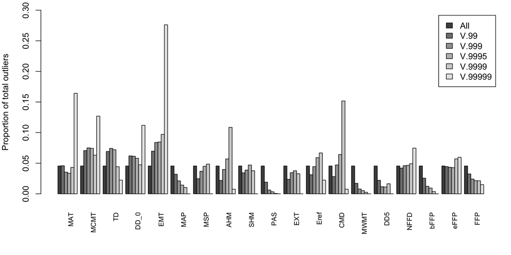

See the environmentSummary.html for information on the environments and their abbreviations. The x-axis is sorted according to groups. MAT to EMT is Group 1; MAP to CMD is Group 2, and MWMT to FFP is Group 3.

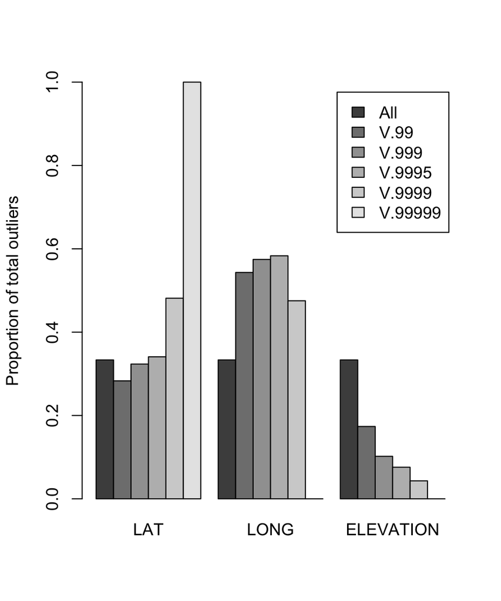

Similar to results from all SNPs.

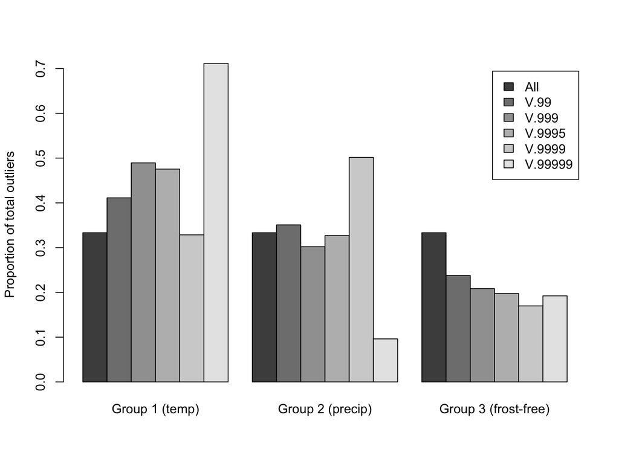

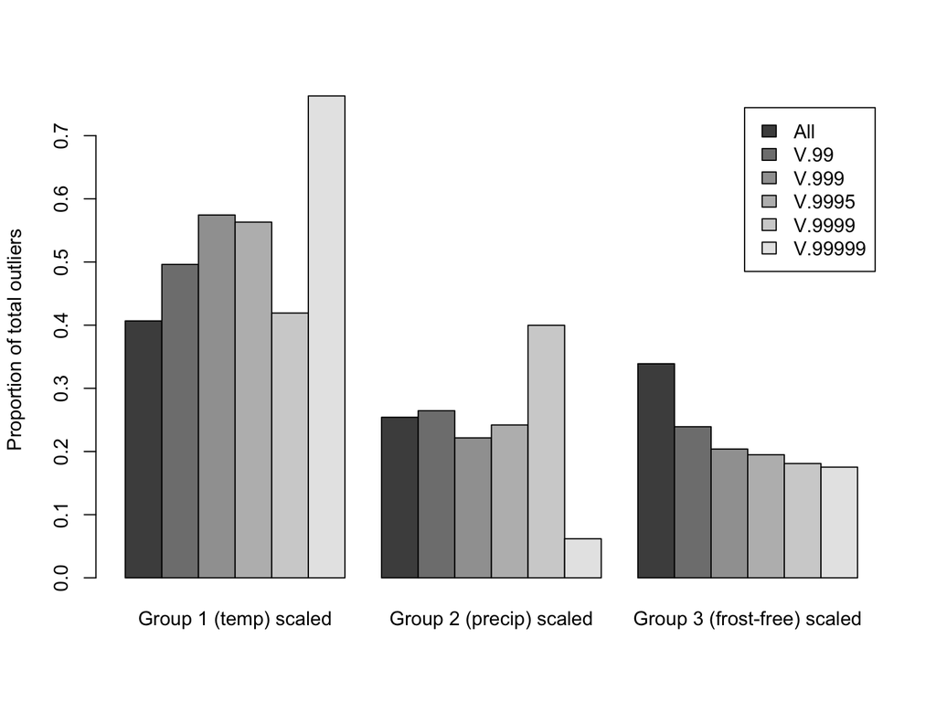

Similar to results from all SNPs.

##### Results based on annotation category

```r
  levels(f2b$X.annotation)
```

```
##   [1] "3primeFLANK"     "3primeUTR"       "5primeFLANK"
##   [4] "5primeUTR"       "HAS_INDEL"       "intron"
##   [7] "mismatch_altref" "multi-allelic"   "non_tcontig"
##  [10] "nonsyn___to_C"   "nonsyn___to_E"   "nonsyn___to_G"
##  [13] "nonsyn___to_K"   "nonsyn___to_L"   "nonsyn___to_Q"
##  [16] "nonsyn___to_R"   "nonsyn___to_S"   "nonsyn___to_W"
##  [19] "nonsyn___to_Y"   "nonsyn_A_to_D"   "nonsyn_A_to_E"
##  [22] "nonsyn_A_to_G"   "nonsyn_A_to_P"   "nonsyn_A_to_S"
##  [25] "nonsyn_A_to_T"   "nonsyn_A_to_V"   "nonsyn_C_to__"
##  [28] "nonsyn_C_to_F"   "nonsyn_C_to_G"   "nonsyn_C_to_R"
##  [31] "nonsyn_C_to_S"   "nonsyn_C_to_W"   "nonsyn_C_to_Y"
##  [34] "nonsyn_D_to_A"   "nonsyn_D_to_E"   "nonsyn_D_to_G"
##  [37] "nonsyn_D_to_H"   "nonsyn_D_to_N"   "nonsyn_D_to_V"
##  [40] "nonsyn_D_to_Y"   "nonsyn_E_to__"   "nonsyn_E_to_A"
##  [43] "nonsyn_E_to_D"   "nonsyn_E_to_G"   "nonsyn_E_to_K"
```

[output cut: 46 more lines]

```r
### Make a new annotation category
    new.annot <- as.character(unlist(f2b$X.annotation))
    new.annot[grep("nonsyn", f2b$X.annotation)] <- "nonsyn"
    new.annot <- as.factor(new.annot)
    levels(new.annot)
```

```
##  [1] "3primeFLANK"     "3primeUTR"       "5primeFLANK"
##  [4] "5primeUTR"       "HAS_INDEL"       "intron"
##  [7] "mismatch_altref" "multi-allelic"   "non_tcontig"
## [10] "nonsyn"          "synonymous"      "unk_adj"
## [13] "unk_flank"       "UNKNOWN_ORF"
```

```
## [1] 15
## [1] 15
## [1] 15
## [1] 15
## [1] 15
```

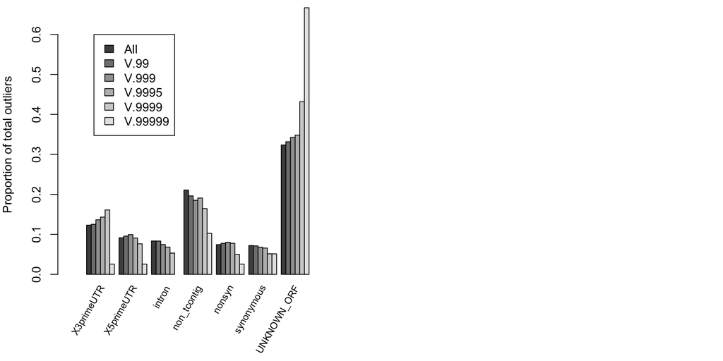

```r
### Calculate the max(BF) for a locus across all environments
  if(!("max.BFb" %in% ls())){
  max.BFb <- apply(f2b[,colBF], 1, max, na.rm=TRUE)
  max.BFb[is.infinite(max.BFb)]<-NA
  }

### functions to get proportions
get.prop.newannot <- function(V, ind, rowname=NULL){
  a<- tapply(V[ind], new.annot[ind], length)
  a2<- data.frame(t(a/sum(a, na.rm=TRUE)))
  rownames(a2) <- rowname
  a2
  }

### For barplot, x-axis categories are in columns and colored bars are in rows
  enrich.new.annot <- data.frame(cutoff="All", get.prop.newannot(max.BFb, TRUE))

  cutoff2 <- as.numeric(cos[1,4:8])
  cutoff2names <- names(cos[1,4:8])
  for (i in 1:length(cutoff2)){
    n2 <- data.frame(cutoff=cutoff2names[i], get.prop.newannot(max.BFb, max.BFb>=cutoff2[i]) )
    print(length(n2))
    enrich.new.annot<- merge(enrich.new.annot, n2, all.x=TRUE, all.y=TRUE)
  }
```

These results differ slightly from the whole SNP set.

#### Results based on proportion of noncoding SNPs used in covariance matrix

```r
levels(f2b$noncode_in_covar)
```

```
## [1] "in_covar" "no"
```

```r
get.prop.noncod <- function(V, ind){
  a<- tapply(V[ind], f2b$noncode_in_covar[ind], length)
  as.numeric((a/sum(a, na.rm=TRUE))[1])
  }

  enrich.noncod <- get.prop.noncod(max.BFb, TRUE)
  for (i in 1:length(cutoff2)){
    enrich.noncod <- c(enrich.noncod, get.prop.noncod(max.BFb, max.BFb>=cutoff2[i]) )
  }
  names(enrich.noncod) <- c("All", cutoff2names)
  enrich.noncod
```

```
##         All        V.99       V.999      V.9995      V.9999     V.99999
## 0.018177852 0.017312988 0.019855596 0.022600721 0.009966777          NA
```

#### Histogram of BF from noncoding SNPs used in covmat vs. other SNPs

```r
 low <- min(max.BFb, na.rm=TRUE)
 high <- max(max.BFb, na.rm=TRUE)
levels(f2b$noncode_in_covar)
```

```
## [1] "in_covar" "no"
```

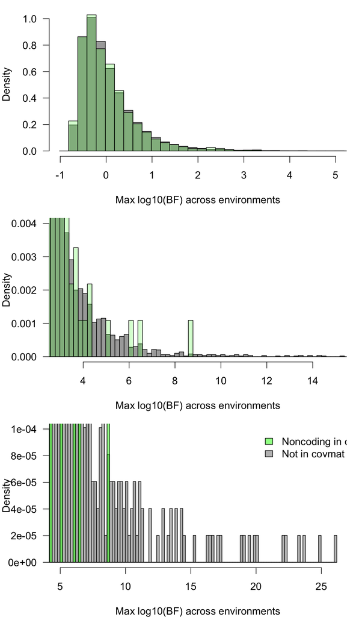

```r
#[1] "in_covar" "no"
  br <- seq(low-0.2, high+0.2, by=0.2)
  par(mfcol=c(3,1), mar=c(4,4,1,1), cex=1.2, las=1)
  hist(max.BFb[f2b$noncode_in_covar=="no"], breaks=br, freq=FALSE, col="darkgrey", xlim=c(-1,5), main="", xlab="Max log10(BF) across environments")
  hist(max.BFb[f2b$noncode_in_covar=="in_covar"], breaks=br, freq=FALSE, add=TRUE, col=rgb(0,1,0,0.2))

  hist(max.BFb[f2b$noncode_in_covar=="no"], breaks=br, xlim=c(3, 15), freq=FALSE, ylim=c(0,0.004),  main="", xlab="Max log10(BF) across environments", col="darkgrey")
  hist(max.BFb[f2b$noncode_in_covar=="in_covar"], breaks=br, freq=FALSE, add=TRUE, col=rgb(0,1,0,0.2))

  hist(max.BFb[f2b$noncode_in_covar=="no"], breaks=br, xlim=c(5, high), freq=FALSE, ylim=c(0,0.0001),  main="", xlab="Max log10(BF) across environments", col="grey")
  hist(max.BFb[f2b$noncode_in_covar=="in_covar"], breaks=br, freq=FALSE, add=TRUE, col=rgb(0,1,0,0.5))
  legend(20,0.0001, c("Noncoding in covmat", "Not in covmat"), fill=c(rgb(0,1,0,0.5),"grey" ), bty="n")
```

### Why are these results similar?

1. Because the LFMM dataset only used SNPs that were present in a majority of individuals:

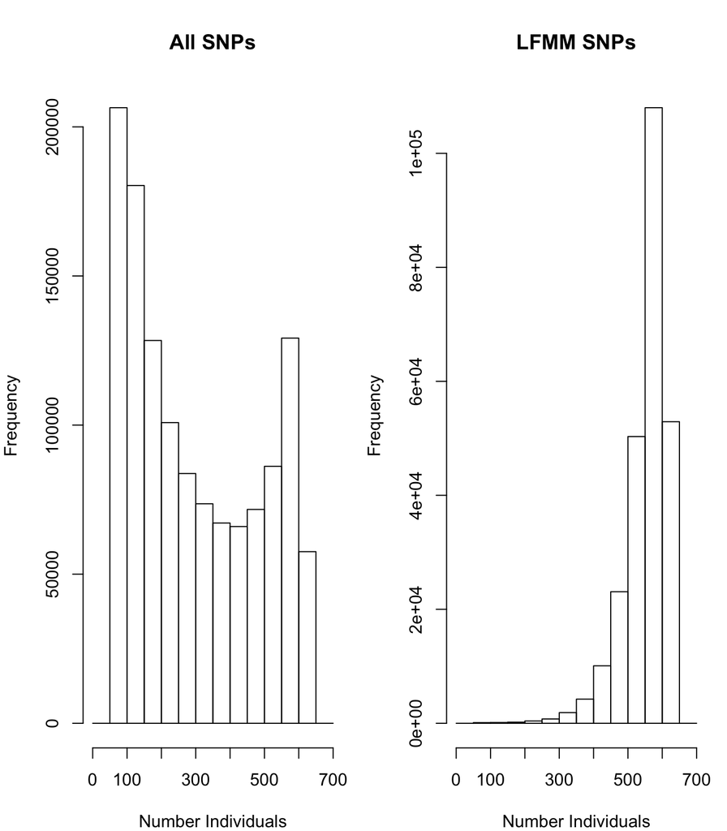

```r
par(mfrow=c(1,2), mar=c(4,4,4,1))
hist(f2$num_ind, main="All SNPs", xlab="Number Individuals", breaks=seq(0,700,50))
hist(f2b$num_ind, main="LFMM SNPs", xlab="Number Individuals", breaks=seq(0,700,50))
```

and 2) Bayes Factors are higher in SNPs that have more data. (The same thing happens with p-values; they are smaller when we have more data).

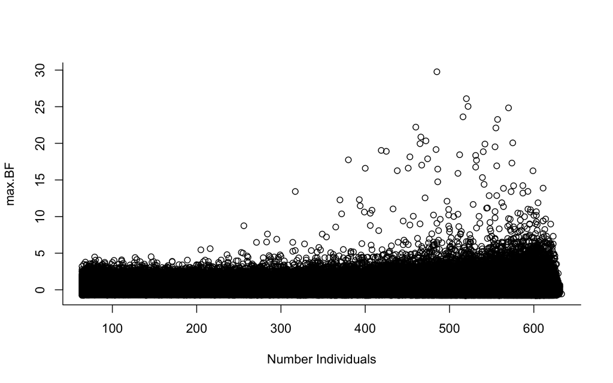

```r
par(mfrow=c(1,1))
plot(f2$num_ind, max.BF, bty="l", xlab="Number Individuals")
```